# Intervalos de confiança usando o método Bootstrap

## Resumo

O documento a seguir explica e exemplifica a criação de intervalos de confiança usando uma opção formidável para casos que exigem abordagens não-paramétricas, um método conhecido como Bootstrap.

**🔹**Definição**: Bootstrap é um método computacional que faz usa uma amostra original de uma população para criar inúmeras outras por meio de um procedimento chamado reamostragem, em geral, com reposição. O objetivo é chegar a uma distribuição amostral empírica de uma estatística de interesse, permitindo realizar inferências como Intervalos de Confiança.**

[Fonte](https://www.blog.psicometriaonline.com.br/reamostragem-e-o-metodo-bootstrap/)

## Exemplo 1

O objetivo é determinar um IC para a mediana, a partir de uma amostra $X = (X_1, X_2, ... , X_n)$. A maior diferença para esse caso em comparação a um IC para a média, por exemplo, é que aqui não podemos usar livremente a distribuição t-student ou o teorema do limite central, principalmente por não ser uma população que segue uma distribuição normal, por isso precisamos do método Bootstrap.

> Dada uma amostra X, queremos determinar um IC para a mediana e os quartis dos dados, porém sem assumir nenhuma distribuição (abordagem não-paramétrica).

**📌 Clique para ver a resolução**

Usarei uma amostra aleatória usando a função `rgamma` para gerar os dados., que serão assimétricos. Abaixo, segue um resumo enumerado dos passos realizados neste procedimento.

Foi considerado um nível de confiança de 95% $(\alpha = 0.05)$. Além disso, a amostra original é de tamanho n = 100, de modo que teremos 100.000 novos dados com as (re)amostras, nos permitindo encontrar um IC mais confiável para a mediana.

1. Reamostragem: Gerar n valores com reposição B vezes
2. Calcular a estatística de interesse com a nova amostra
3. O IC resultante é formado

### Análise gráfica

Além do IC resultante, podemos ver também o histograma, cujas linhas tracejadas representam os limites inferior e superior do intervalo de confiança, enquanto a linha curva amarela mostra a densidade, que inclusive me surpreendeu um pouco, porque eu esperava uma curva mais próxima de uma curva normal, com as 1000 reamostragens.

```r
#SET SEED PARA GERAR A MESMA AMOSTRA
func <- function(x){sin(x)^2 + cos(x)^2}
set.seed(integrate(func, upper = 8, lower = 1)$value)


X <- rgamma(100, shape=2, scale=2)
B <- 1000
n <- length(X)
medianas <- numeric(B)


for(i in 1:B) {
  reamost <- sample(X, size = n, replace = TRUE)
  medianas[i] <- median(reamost)
}

alpha <- 0.05
lim_inf <- quantile(medianas, alpha/2)
lim_sup <- quantile(medianas, 1-alpha/2)

cat("IC(95%) - Mediana: [", round(lim_inf, 4), " ; ", round(lim_sup, 4), "]")
```

IC(95%) - Mediana: [ 3.7918 ; 4.7802 ]

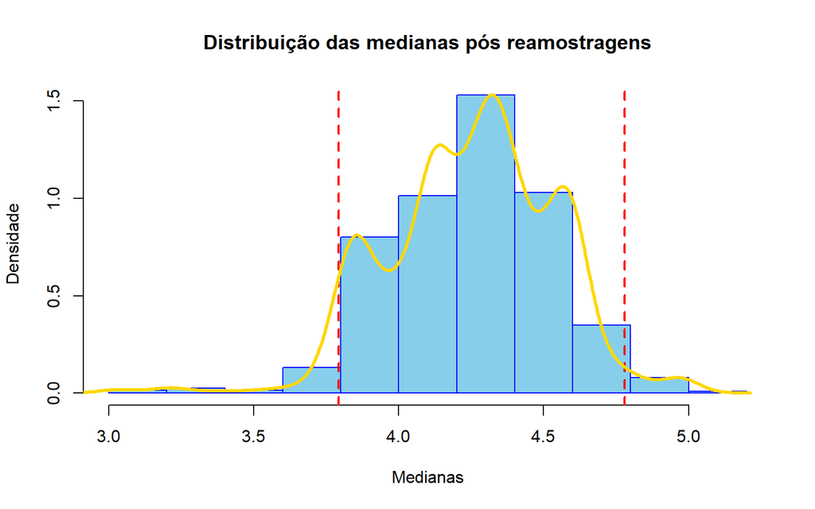

```r
hist(medianas, prob = T, main = "Distribuição das medianas pós reamostragens",
     xlab = "Medianas", ylab = "Densidade", col = "skyblue", border = "blue")
abline(v = c(lim_inf, lim_sup), col = "red", lwd = 2, lty = 2)
lines(density(medianas), col = "gold", lwd = 3)
```

## Exemplo 2

O objetivo nesse caso é criar um IC para o coeficiente de correlação entre duas variáveis X e Y que, a saber, representam notas de duas avaliações de (provavelmente) alunos enumerados de 1 a n.

> Dada a amostra $(X_1, X_2,...,X_n)\ e\ (Y_1, Y_2,...,Y_n)$ e indivíduos $\in {1,2,...,n}$, fazer um IC para a correlação entre X e Y

**Importante**: Nesse caso, estamos lidando com uma amostra de dados pareados, i.e, que estão correlacionados, como o próprio enunciado no slide deixou claro. Ou seja, precisamos comparar ambas as notas de de cada alunos, i.e, cada par $(x_i, y_i)$

**📌 Clique para ver a resolução**

No código abaixo, utilizei uma relação linear qualquer, de modo que Y dependa de X, inclusive configurei as amostras aleatórias `rnorm` de modo que (espero) tenham uma boa chance de ficar entre 0 e 10, para se parecer mais com resultados de provas.

1. Criação das amostras aleatórias usando `rnorm` (acredito fazer mais sentido no caso de notas, pois se usássemos uma distribuição assimétrica poderia não fazer sentido na prática, apesar dos resultados matemáticos estarem teoricamente corretos)
2. (Re)amostras criadas a partir da amostra original, mas usando os índexes, de modo a comparar notas pareadas (do mesmo indivíduo antes e depois)
3. Construção do IC usando os quantis

### Análise gráfica

Assim como no exemplo anterior, as linhas tracejada vermelhas indicam os limites inferior e superior do IC criado, enquanto a linha curva amarela representa a densidade. E dessa vez temos uma curva mais próxima de um formato gaussiano (em sino)!

```r
#NOVAMENTE, A MELHOR SEED
func <- function(x){sin(x)^2 + cos(x)^2}
set.seed(integrate(func, upper = 8, lower = 1)$value)

n <- 100
X <- rnorm(n, mean = 5, sd = 1.5)
Y <- X*sqrt(0.6) + rnorm(n, mean = 0, sd = 2) #para existir correlação

B <- 1000
correlacoes <- numeric(B)

for(i in 1:B) {
  index <- sample(1:n, size = n, replace = T)

  X_reamost <- X[index]
  Y_reamost <- Y[index]

  correlacoes[i] <- cor(X_reamost, Y_reamost)
}

alpha <- 0.05
lim_inf <- quantile(correlacoes, alpha/2)
lim_sup <- quantile(correlacoes, 1-alpha/2)

cat("Correlação:", cor(X,Y))
```

Correlação: 0.5125638

```r
cat("IC(95%) - Correlação:[", round(lim_inf, 4), " ; ", round(lim_sup, 4), "]")
```

IC(95%) - Correlação:[ 0.3606 ; 0.6507 ]

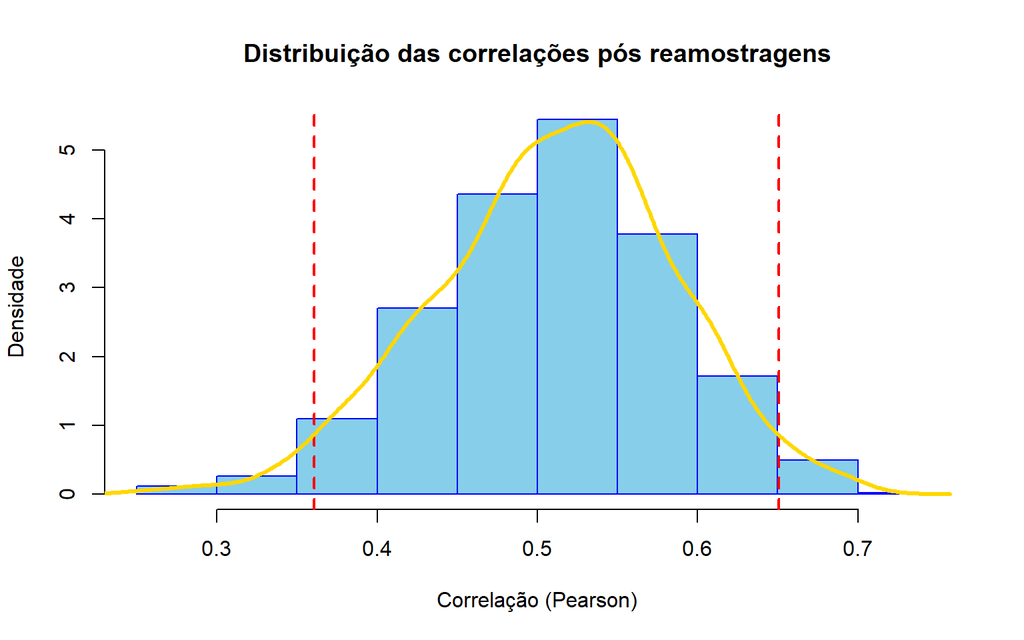

```r
hist(correlacoes, prob = T, main = "Distribuição das correlações pós reamostragens",
     xlab = "Correlação (Pearson)", ylab = "Densidade", col = "skyblue", border = "blue")
abline(v = c(lim_inf, lim_sup), col="red", lwd = 2, lty = 2)
lines(density(correlacoes), col = "gold", lwd = 3)
```

### Conclusão

**📌 Clique para ver a conclusão**

Falando mais pessoalmente, eu vejo eu método Bootstrap de forma até um pouco cômica! Porque desde que eu o havia descoberto, pensei que a lógica fosse basicamente “Fazer algo se repetir tantas vezes até tirar à força um resultado decente desses dados”, ou seja, repetir tanto quanto necessário para diminuir a incerteza e aumentar a precisão de inferências. E após realizar este trabalho, vi que não é tão complicado como pensei que fosse!

E agora, haja visto os resultados acima, podemos concluir que é um método robusto, e uma ótima opção para casos não-paramétricos já que, de forma semelhante ao TLC, ele aumenta as chances de nos aproximarmos de forma correta da distribuição dos dados criando novas amostras a partir da original, quase que como uma mitose dos dados.

É um método genial que exige apenas que tenhamos dados para analisar, e nos entrega um resultado, em geral, satisfatório e confiável, e podemos aumentar essa confiança aumentando o número de reamostragens. Entretanto, penso que haja um certo limite para isso, pois por mais que aumentemos exacerbadamente a quantidade de novas amostras geradas, o Bootstrap não é um método milagroso, portanto, a partir de certo ponto não teremos mais nada a ganhar aumentando o intensivo trabalho computacional, i.e, quanto menor a amostra original, não só menor é a eficácia do Bootstrap, como também logo atingiremos o platô, com poucas reamostras já chegaremos ao limite do que ele pode nos proporcionar.